# Assignment 6.1 GSS 2016 Survey Data

Larry Heckel

April 16, 2019

# Assignment 6.1 GSS 2016 Survey Data

Work with your previously assigned team members on this assignment. Data for this assignment originated from the General Society Survey (GSS). The GSS gathers data on contemporary American society in order to monitor and explain trends and constants in attitudes, behaviors, and attributes. Hundreds of trends have been tracked since 1972. In addition, since the GSS adopted questions from earlier surveys, trends can be followed for up to 70 years. Only data from the 2016 GSS survey is included in this dataset – GSS2016.csv.

If you are interested in getting at a different year or a cumulative dataset you can visit http://www.gss.norc.org

For this assignment, you will need to load and activate the ggplot2 package. You are encouraged to complete the assigned reading and DataCamp exercises before starting their work. Each of you should first produce your own version of the following deliverables then share with your team members. Team members will then collaborate on their approach and insights, refining their work before submitting for a grade.

As a data science intern with newly learned knowledge in skills in statistical correlation, regression and R programming, you are interested in looking at the GSS 2016 survey data, specifically the Siblings and Childs variables have peaked your interest. A codebook for the GSS is available here: GSS_Codebook_Index.pdf and contains all of the GSS variables and descriptions.

The first question you are interested in answering is: “Is there a significant relationship between the number of siblings a survey respondent has and number of his or her children?”

The following guidelines describe minimum deliverables needed for the assignment submission.

# Part 1 Assignment

1. Construct a scatterplot of these two variables in R studio and place the best-fit linear regression line on the scatterplot. Describe the relationship between the number of siblings a respondent has (SIBS) and the number of his or her children (CHILDS).
2. Use R to calculate the covariance of the two variables and provide an explanation of why you would use this calculation and what the results indicate.
3. Choose the type of correlation test to perform, explain why you chose this test, and make a prediction if the test yields a positive or negative correlation?
4. Perform a correlation analysis of the two variables and describe what the calculations in the correlation matrix suggest about the relationship between the variables. Be specific with your explanation.
5. Calculate the correlation coefficient and the coefficient of determination, describe what you conclude about the results.
6. Based on your analysis, what can you say about the relationship between the number of siblings and the number of his or her children?
7. Produce an appropriate graph for the variables. Report, critique and discuss the skewness and any significant scores found.
8. Expand your analysis to include a third variable – Sex. Perform a partial correlation, “controlling” the Sex variable. Explain how this changes your interpretation and explanation of the results.

Report and discuss all of your calculations and critiques using R Markdown.

# Part 2 Assignment

1. Run a regression analysis where SIBS predicts CHILDS.
2. What are the intercept and the slope? What are the coefficient of determination and the correlation coefficient?
3. For this model, how do you explain the variation in the number of children someone has? What is the amount of variation not explained by the number of siblings?
4. Based on the calculated F-Ratio does this regression model result in a better prediction of the number of children than if you had chosen to use the mean value of siblings?
5. Use the model to make a prediction: What is the predicted number of children for someone with three siblings?
6. Use the model to make a prediction: What is the predicted number of children for someone without any siblings?

```r
#libraries to use
library(ggplot2)
library(readr)
library(dplyr)
library(stringr)
library(psych)
library(janitor)
library(car)
library(QuantPsyc)
library(pastecs)
library(ggm)
#read and examine the source data
gss2016 <- read_csv("gss-2016.csv", guess_max = 3000)
#str(gss2016)
head(gss2016)
```

```
## # A tibble: 6 x 960
##    MAR1  MAR2  MAR3  MAR4  MAR5  MAR6  MAR7  MAR8  MAR9 MAR10 MAR11 MAR12
##   <dbl> <dbl> <dbl> <dbl> <dbl> <dbl> <dbl> <dbl> <dbl> <lgl> <dbl> <dbl>
## 1     1     1     5     5    NA    NA    NA    NA    NA NA       NA    NA
## 2     4    NA    NA    NA    NA    NA    NA    NA    NA NA       NA    NA
## 3     1     1    NA    NA    NA    NA    NA    NA    NA NA       NA    NA
## 4     1     1     5     4     5     5    NA    NA    NA NA       NA    NA
## 5     1     1     5    NA    NA    NA    NA    NA    NA NA       NA    NA
## 6     1     1     5    NA    NA    NA    NA    NA    NA NA       NA    NA
## # … with 948 more variables: MAR13 <dbl>, MAR14 <lgl>, ABANY <dbl>,
## #   ABDEFECT <dbl>, ABHLTH <dbl>, ABNOMORE <dbl>, ABPOOR <dbl>,
## #   ABRAPE <dbl>, ABSINGLE <dbl>, ACQNTSEX <dbl>, ADFORJOB <dbl>,
## #   ADULTS <dbl>, ADVFRONT <dbl>, ADVSCHED <dbl>, AFFRMACT <dbl>,
## #   AGE <dbl>, AGE3 <dbl>, AGED <dbl>, AGEDCHLD <dbl>, AGEDPAR <dbl>,
## #   AGEKDBRN <dbl>, AIDCOL <dbl>, AIDHOUSE <dbl>, AIDINDUS <dbl>,
## #   AIDOLD <dbl>, AIDUNEMP <dbl>, APPEMPS <dbl>, ARTATT <dbl>,
## #   ARTATT1 <dbl>, ARTATT2 <dbl>, ARTATT3 <dbl>, ARTATT4 <dbl>,
## #   ARTATT5 <dbl>, ARTCOST <dbl>, ARTEXBT <dbl>, ARTFREE <dbl>,
## #   ARTGST <dbl>, ARTINT <dbl>, ARTLOC <dbl>, ARTMOSTOTH <dbl>,
## #   ARTOTHR <dbl>, ARTTIME <dbl>, ARTTRVL <dbl>, ARTWHY1 <dbl>,
## #   ARTWHY2 <dbl>, ARTWHY3 <dbl>, ARTWHY4 <dbl>, ARTWHY5 <dbl>,
## #   ARTWHY6 <dbl>, ARTWHY7 <dbl>, ARTWHY8 <dbl>, ARTWHY9 <dbl>,
## #   ASKHELP <dbl>, ASTROLGY <dbl>, ASTROSCI <dbl>, ATTEND <dbl>,
## #   AWAY1 <dbl>, AWAY11 <dbl>, AWAY13 <dbl>, AWAY2 <dbl>, AWAY3 <dbl>,
## #   AWAY4 <dbl>, AWAY5 <dbl>, AWAY6 <dbl>, AWAY7 <dbl>, BABIES <dbl>,
## #   BALLOT <dbl>, BALNEG <dbl>, BALPOS <dbl>, BETRLANG <dbl>, BIBLE <dbl>,
## #   BIGBANG <dbl>, BIGBANG1 <dbl>, BIGBANG2 <dbl>, BORED <dbl>,
## #   BORN <dbl>, BOSSEMPS <dbl>, BOYORGRL <dbl>, BRIBE <dbl>,
## #   BRLAWFL <dbl>, BRNOTAX <dbl>, CAPPUN <dbl>, CCTV <dbl>, CESD1 <dbl>,
## #   CESD2 <dbl>, CESD3 <dbl>, CESD4 <dbl>, CESD5 <dbl>, CHEMGEN <dbl>,
## #   CHILDS <dbl>, CHLDIDEL <dbl>, CHNGEWRK <dbl>, CLASS <dbl>,
## #   CLOSEBLK <dbl>, CLOSEWHT <dbl>, CLSSMTES <dbl>, CODEG <dbl>,
## #   CODEN <dbl>, CODIPGED <dbl>, COEDUC <dbl>, …
```

```r
#use the janitor package to remove empty rows and columns
gss2016Clean <- remove_empty(gss2016, which = c("rows","cols"))
head(gss2016Clean)
```

```
## # A tibble: 6 x 958
##    MAR1  MAR2  MAR3  MAR4  MAR5  MAR6  MAR7  MAR8  MAR9 MAR11 MAR12 MAR13
##   <dbl> <dbl> <dbl> <dbl> <dbl> <dbl> <dbl> <dbl> <dbl> <dbl> <dbl> <dbl>
## 1     1     1     5     5    NA    NA    NA    NA    NA    NA    NA    NA
## 2     4    NA    NA    NA    NA    NA    NA    NA    NA    NA    NA    NA
## 3     1     1    NA    NA    NA    NA    NA    NA    NA    NA    NA    NA
## 4     1     1     5     4     5     5    NA    NA    NA    NA    NA    NA
## 5     1     1     5    NA    NA    NA    NA    NA    NA    NA    NA    NA
## 6     1     1     5    NA    NA    NA    NA    NA    NA    NA    NA    NA
## # … with 946 more variables: ABANY <dbl>, ABDEFECT <dbl>, ABHLTH <dbl>,
## #   ABNOMORE <dbl>, ABPOOR <dbl>, ABRAPE <dbl>, ABSINGLE <dbl>,
## #   ACQNTSEX <dbl>, ADFORJOB <dbl>, ADULTS <dbl>, ADVFRONT <dbl>,
## #   ADVSCHED <dbl>, AFFRMACT <dbl>, AGE <dbl>, AGE3 <dbl>, AGED <dbl>,
## #   AGEDCHLD <dbl>, AGEDPAR <dbl>, AGEKDBRN <dbl>, AIDCOL <dbl>,
## #   AIDHOUSE <dbl>, AIDINDUS <dbl>, AIDOLD <dbl>, AIDUNEMP <dbl>,
## #   APPEMPS <dbl>, ARTATT <dbl>, ARTATT1 <dbl>, ARTATT2 <dbl>,
## #   ARTATT3 <dbl>, ARTATT4 <dbl>, ARTATT5 <dbl>, ARTCOST <dbl>,
## #   ARTEXBT <dbl>, ARTFREE <dbl>, ARTGST <dbl>, ARTINT <dbl>,
## #   ARTLOC <dbl>, ARTMOSTOTH <dbl>, ARTOTHR <dbl>, ARTTIME <dbl>,
## #   ARTTRVL <dbl>, ARTWHY1 <dbl>, ARTWHY2 <dbl>, ARTWHY3 <dbl>,
## #   ARTWHY4 <dbl>, ARTWHY5 <dbl>, ARTWHY6 <dbl>, ARTWHY7 <dbl>,
## #   ARTWHY8 <dbl>, ARTWHY9 <dbl>, ASKHELP <dbl>, ASTROLGY <dbl>,
## #   ASTROSCI <dbl>, ATTEND <dbl>, AWAY1 <dbl>, AWAY11 <dbl>, AWAY13 <dbl>,
## #   AWAY2 <dbl>, AWAY3 <dbl>, AWAY4 <dbl>, AWAY5 <dbl>, AWAY6 <dbl>,
## #   AWAY7 <dbl>, BABIES <dbl>, BALLOT <dbl>, BALNEG <dbl>, BALPOS <dbl>,
## #   BETRLANG <dbl>, BIBLE <dbl>, BIGBANG <dbl>, BIGBANG1 <dbl>,
## #   BIGBANG2 <dbl>, BORED <dbl>, BORN <dbl>, BOSSEMPS <dbl>,
## #   BOYORGRL <dbl>, BRIBE <dbl>, BRLAWFL <dbl>, BRNOTAX <dbl>,
## #   CAPPUN <dbl>, CCTV <dbl>, CESD1 <dbl>, CESD2 <dbl>, CESD3 <dbl>,
## #   CESD4 <dbl>, CESD5 <dbl>, CHEMGEN <dbl>, CHILDS <dbl>, CHLDIDEL <dbl>,
## #   CHNGEWRK <dbl>, CLASS <dbl>, CLOSEBLK <dbl>, CLOSEWHT <dbl>,
## #   CLSSMTES <dbl>, CODEG <dbl>, CODEN <dbl>, CODIPGED <dbl>,
## #   COEDUC <dbl>, COEVWORK <dbl>, COFUND <dbl>, …
```

A couple of comments on the above code, in reading and examining the file.

1. I had to add the “guess_max” parameter to ensure that read_csv assigned the correct variable type to each column. Over 30 columns did not have an actual value until after the 1,000th row, resulting in an incorrect type assignment, and therefore a parsing error in the read.
2. The data is exceptionally sparse, so I added the janitor package in order to attempt to eliminate some of the rows/columns that had no data in them. No rows, and only two columns, contained no data, so while the effort was worth trying, it did not yield appreciable results, so I will continue with the original data frame.
3. Finally, given the data sparseness, were I looking to store this in a database, I might think about using some form of NoSQL solution, in which the data records only contain the key-value pairs for which there is data. YEAR and ID are the key values, and all others have data only based on the respondent answers. Just a thought.

## Part 1

#### a. Construct a scatterplot of these two variables in R studio and place the best-fit linear regression line on the scatterplot. Describe the relationship between the number of siblings a respondent has (SIBS) and the number of his or her children (CHILDS).

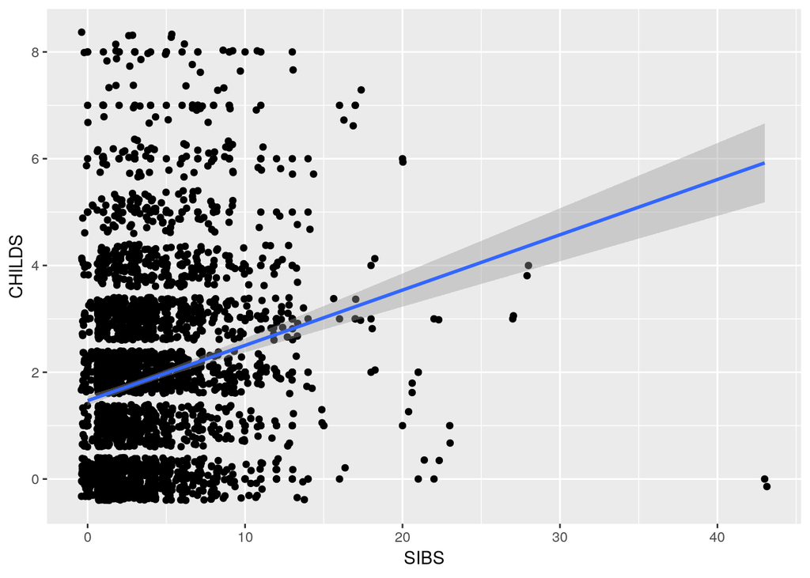

```r
sibChildlm <- lm(gss2016$CHILDS ~ gss2016$SIBS, na.action=na.omit)
sibChildlm
```

```
##
## Call:
## lm(formula = gss2016$CHILDS ~ gss2016$SIBS, na.action = na.omit)
##
## Coefficients:
##  (Intercept)  gss2016$SIBS
##        1.468         0.104
```

```r
summary(sibChildlm)
```

```
##
## Call:
## lm(formula = gss2016$CHILDS ~ gss2016$SIBS, na.action = na.omit)
##
## Residuals:
##    Min     1Q Median     3Q    Max
## -5.922 -1.571  0.014  1.014  6.532
##
## Coefficients:
##              Estimate Std. Error t value            Pr(>|t|)
## (Intercept)   1.46777    0.04689    31.3 <0.0000000000000002 ***
## gss2016$SIBS  0.10358    0.00956    10.8 <0.0000000000000002 ***
## ---
## Signif. codes:  0 '***' 0.001 '**' 0.01 '*' 0.05 '.' 0.1 ' ' 1
##
## Residual standard error: 1.6 on 2854 degrees of freedom
##   (11 observations deleted due to missingness)
## Multiple R-squared:  0.0395, Adjusted R-squared:  0.0392
## F-statistic:  118 on 1 and 2854 DF,  p-value: <0.0000000000000002
```

In this analysis, the outcome variable is CHILDS, the number of children the respondent has, and the predictor variable is SIBS, the number of siblings that the respondent has. In order to understand the relationship between the two variables, the regression line’s slope gives the change in the outcome variable associated with a single unit change in the predictor variable. In this case, the model predicts that each additional sibling the responder has leads to 0.104 additional children for the responder.

#### b. Use R to calculate the covariance of the two variables and provide an explanation of why you would use this calculation and what the results indicate.

```r
covSibChild <- cov(gss2016$CHILDS, gss2016$SIBS, use = "pairwise.complete.obs")
covSibChild
```

```
## [1] 1.1
```

Covariance is a measure of how two variables are related to each other. The measure indicates how each of the variables deviates from its mean value, in relation to the other variable. A positive covariance indicates that as one variable deviates from its mean, the other one deviates in the same direction (positive-positive or negative-negative). A negative covariance indicates that as one deviates from its mean, the other changes in the opposite direction (positive-negative).

In general, the larger the covariance, the stronger the relationship, and the magnitude of the value, and the strength, depends on the scale of the two variables. In this case, both of the variables have the same scale, the number of people defined (sibling or child).

The reason for using this measurement is that it provides a simple metric to describe the relationship between the two variables.

#### c. Choose the type of correlation test to perform, explain why you chose this test, and make a prediction if the test yields a positive or negative correlation?

The correlation test will be the Pearson correlation coefficient, because it provides a value on a standard scale from -1 to +1, from perfect negative to perfect positive correlation. I predict that there will be a positive correlation, the same as the covariance showed.

#### d. Perform a correlation analysis of the two variables and describe what the calculations in the correlation matrix suggest about the relationship between the variables. Be specific with your explanation.

```r
corSibChild <- cor.test(gss2016$SIBS, gss2016$CHILDS, use="pairwise.complete.obs", method="pearson")
corSibChild
```

```
##
##  Pearson's product-moment correlation
##
## data:  gss2016$SIBS and gss2016$CHILDS
## t = 10, df = 3000, p-value <0.0000000000000002
## alternative hypothesis: true correlation is not equal to 0
## 95 percent confidence interval:
##  0.16 0.23
## sample estimates:
## cor
## 0.2
```

The Pearson correlation coefficient is 0.2, and the 95% confidence interval range is 0.16-0.23. Because this range does not cross 0, we are confident in the positive relationship between number of siblings and number of children. In the case of this analysis, the null hypothesis is that the correlation is 0, and the computed p-value < 0.001 provides strong evidence against this null hypothesis, so we reject it and accept the alternative hypothesis, that the true correlation is not equal to 0, concluding that the correlation is as computed.

#### e. Calculate the correlation coefficient and the coefficient of determination, describe what you conclude about the results.

Correlation Coefficient

```r
cor(gss2016$SIBS, gss2016$CHILDS, use="pairwise.complete.obs", method="pearson")
```

```
## [1] 0.2
```

Coefficient of Determination

```r
cor(gss2016$SIBS, gss2016$CHILDS, use="pairwise.complete.obs", method="pearson")^2
```

```
## [1] 0.04
```

The coefficient of determination is the amount of variability in one variable that is shared by the other. It is a measure of the substantive importance of the relationship between the two variables, and the value is expressed as a percentage.

In the results above, and as computed previously, the correlation coefficient is 0.2, which indicates a relatively weak correlation between number of siblings and number of children. The coefficient of determination is 0.04, meaning that the variability that the two share is only 4%, and that 96% of the variability of each of the two outcomes is dependent upon other factors.

#### f. Based on your analysis, what can you say about the relationship between the number of siblings and the number of his or her children?

In general, parents who come from larger families will also bear larger families, and smaller families in childhood beget smaller families adulthood. This association is not exceptionally strong, however, and we are likely to find other factors that help to drive these outcomes, were we to delve into further analyses.

#### g. Produce an appropriate graph for the variables. Report, critique and discuss the skewness and any significant scores found.

```r
options(scipen=100)
options(digits=2)
stat.desc(gss2016$SIBS)
```

```
##      nbr.val     nbr.null       nbr.na          min          max
##      2862.00       130.00         5.00         0.00        43.00
##        range          sum       median         mean      SE.mean
##        43.00     10642.00         3.00         3.72         0.06
## CI.mean.0.95          var      std.dev     coef.var
##         0.12        10.29         3.21         0.86
```

```r
stat.desc(gss2016$CHILDS, basic = TRUE, norm = TRUE)
```

```
##                                          nbr.val
## 2859.0000000000000000000000000000000000000000000
##                                         nbr.null
##  797.0000000000000000000000000000000000000000000
##                                           nbr.na
##    8.0000000000000000000000000000000000000000000
##                                              min
##    0.0000000000000000000000000000000000000000000
##                                              max
##    8.0000000000000000000000000000000000000000000
##                                            range
##    8.0000000000000000000000000000000000000000000
##                                              sum
## 5295.0000000000000000000000000000000000000000000
##                                           median
##    2.0000000000000000000000000000000000000000000
##                                             mean
##    1.8520461699895067742005494437762536108493805
##                                          SE.mean
##    0.0312204217355784331699997125042500556446612
##                                     CI.mean.0.95
##    0.0612168273590641409676038620091276243329048
##                                              var
##    2.7867094226401545320470631850184872746467590
##                                          std.dev
##    1.6693440096757032886642946323263458907604218
##                                         coef.var
##    0.9013511848277310223309655157208908349275589
##                                         skewness
##    0.9402523085620867471234873846697155386209488
##                                         skew.2SE
##   10.2677089383719675197426113300025463104248047
##                                         kurtosis
##    0.9673600712023393555227812612429261207580566
##                                         kurt.2SE
##    5.2837076766641128955370732001028954982757568
##                                       normtest.W
##    0.8857338671044507893981290180818177759647369
##                                       normtest.p
##    0.0000000000000000000000000000000000000000099
```

```r
#subset the data for siblings up to 22
gss2016SibChild23 <- subset(gss2016,SIBS<23, select = c(SIBS,CHILDS))
#subset the data for siblings up to 14
gss2016SibChild15 <- subset(gss2016,SIBS<15, select = c(SIBS,CHILDS))
```

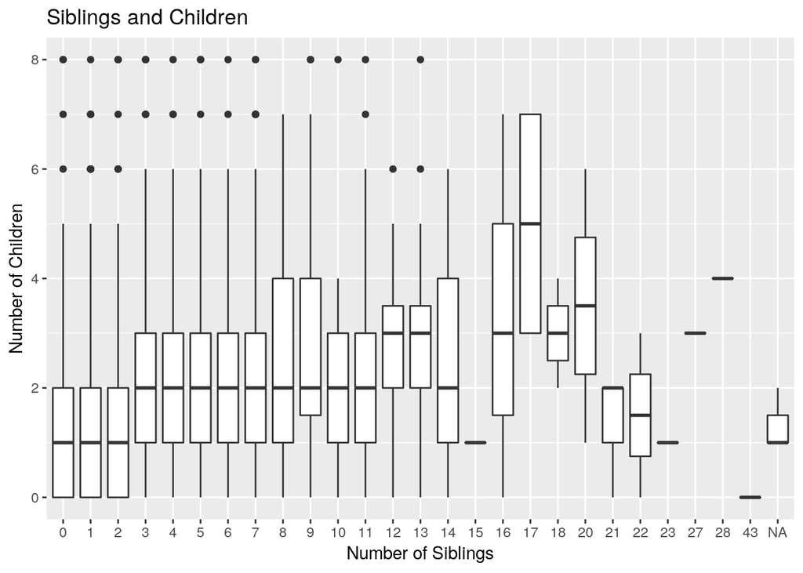

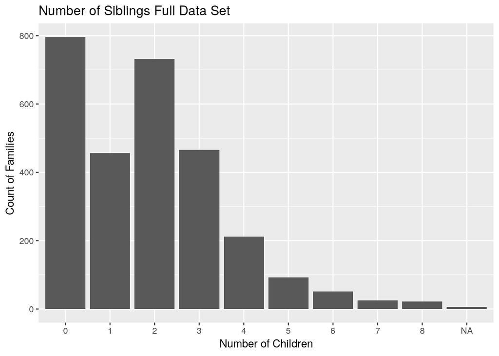

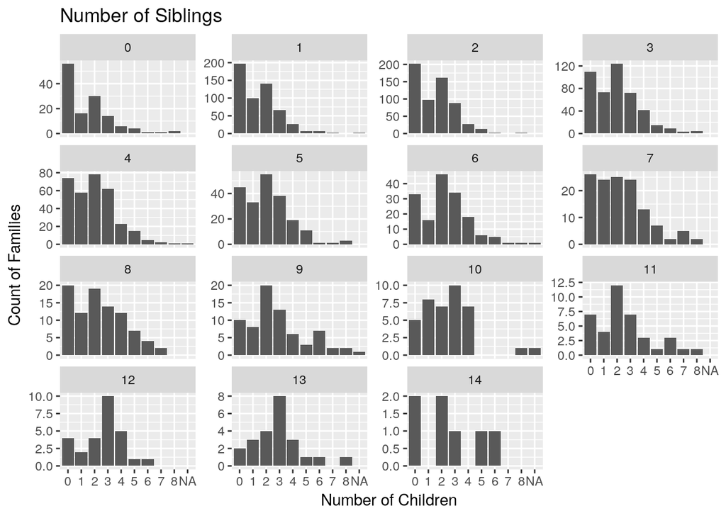

First I ran descriptive statistics on the number of siblings and the number of children. The two statistics that I found interesting were the means and medians of the two variables. The median of the siblings is 3, while it is 2 for the children. Additionally, the mean of the siblings is 3.72, while the childs mean is only 1.85. This basically tells us that that parents in the data gathered are having smaller families than they grew up in. An interesting further analysis about this would be to determine what other factors have effects on the number of children, controlling for number of siblings.

For skew and kurtosis, I focus on the number of children, as it is the dependent variable. The skew value of 0.94 indicates a significant positive skewness, with a long tail to the right.

I created three graphical views of the data.

#### h. Expand your analysis to include a third variable – Sex. Perform a partial correlation, “controlling” the Sex variable. Explain how this changes your interpretation and explanation of the results.

In order to execute the partial correlation, I will subset the data to only the three variables in the computation, and then remove rows with missing data using complete.cases.

```r
gss2016SCS <- subset(gss2016, select = c(SIBS,CHILDS,SEX))
str(gss2016SCS)
```

```
## Classes 'tbl_df', 'tbl' and 'data.frame':    2867 obs. of  3 variables:
##  $ SIBS  : num  2 3 3 3 2 2 2 6 5 1 ...
##  $ CHILDS: num  3 0 2 4 2 2 2 3 3 4 ...
##  $ SEX   : num  1 1 1 2 2 2 1 2 1 1 ...
```

```r
gss2016SCSclean <- gss2016SCS[complete.cases(gss2016SCS),]
str(gss2016SCSclean)
```

```
## Classes 'tbl_df', 'tbl' and 'data.frame':    2856 obs. of  3 variables:
##  $ SIBS  : num  2 3 3 3 2 2 2 6 5 1 ...
##  $ CHILDS: num  3 0 2 4 2 2 2 3 3 4 ...
##  $ SEX   : num  1 1 1 2 2 2 1 2 1 1 ...
```

```r
partCor <- pcor(c("SIBS","CHILDS","SEX"), var(gss2016SCSclean))
partCor
```

```
## [1] 0.2
```

```r
partCor^2
```

```
## [1] 0.039
```

The result of the partial correlation is 0.197, which is nearly identical to the correlation coefficient previously computed. What this means is that the SEX of the parent has little to no effect on the relationship between the number of siblings and number of children, and doesn’t materially change the prior conclusions.

## Part 2

#### a. Run a regression analysis where SIBS predicts CHILDS.

```r
regrSibsChilds <- lm(CHILDS ~ SIBS, gss2016)
regrSibsChilds
```

```
##
## Call:
## lm(formula = CHILDS ~ SIBS, data = gss2016)
##
## Coefficients:
## (Intercept)         SIBS
##       1.468        0.104
```

```r
summary(regrSibsChilds)
```

```
##
## Call:
## lm(formula = CHILDS ~ SIBS, data = gss2016)
##
## Residuals:
##    Min     1Q Median     3Q    Max
## -5.922 -1.571  0.014  1.014  6.532
##
## Coefficients:
##             Estimate Std. Error t value            Pr(>|t|)
## (Intercept)  1.46777    0.04689    31.3 <0.0000000000000002 ***
## SIBS         0.10358    0.00956    10.8 <0.0000000000000002 ***
## ---
## Signif. codes:  0 '***' 0.001 '**' 0.01 '*' 0.05 '.' 0.1 ' ' 1
##
## Residual standard error: 1.6 on 2854 degrees of freedom
##   (11 observations deleted due to missingness)
## Multiple R-squared:  0.0395, Adjusted R-squared:  0.0392
## F-statistic:  118 on 1 and 2854 DF,  p-value: <0.0000000000000002
```

#### b. What are the intercept and the slope? What are the coefficient of determination and the correlation coefficient?

Y-intercept: 1.4678 slope: 0.1036 coefficient of determination: 0.03954

```r
sqrt(.03954)
```

```
## [1] 0.2
```

correlation coefficient: 0.1988467

#### c. For this model, how do you explain the variation in the number of children someone has? What is the amount of variation not explained by the number of siblings?

The coefficient of determination between number of sibling and number of children is 0.04, meaning that the variability that the two share is only 4%, and that 96% of the variability of each of the two outcomes is dependent upon other factors. The parent respondent sex has almost no effect on the number of children, so without further analysis of other potentially contributing variables, 96% of the outcome (number of children) is predicted by unknown factors.

#### e. Use the model to make a prediction: What is the predicted number of children for someone with three siblings?

The linear equation is as follows:

(number children) = 0.1036(number of siblings) + 1.4678

For 3 siblings, the model predicts 1.7786 children.

#### f. Use the model to make a prediction: What is the predicted number of children for someone without any siblings?

The linear equation is as follows:

(number children) = 0.1036(number of siblings) + 1.4678

For 0 siblings, the model predicts 1.4678 children.